# Variable selection and estimation using pointers

Lino Galiana

2018-02-05

This vignette is the occasion to explore the possibilities offered by the `bigmemory` package family to efficiently work with Epidemium data. **For the moment, it is based on a sample of true data: results presented here should not be relied**

We will assume data have been imported using the `OpenCancer` package (see dedicated vignette). A csv file has been stored in a subdirectory `inst` of the current working directory. To see an example, use `/vignettes/inst`, in the package directory. This example dataframe will show the interest of working with C++ pointers rather than dataframes imported in R memory (hence in RAM).

```r
library(OpenCancer)
datadir <- if (stringr::str_detect(getwd(),"/vignettes")) paste0(getwd(),"/inst") else paste0(getwd(),"/vignettes/inst")
```

# Variable selection by LASSO

```r
url <- "https://github.com/EpidemiumOpenCancer/OpenCancer/raw/master/vignettes/inst/exampledf.csv"
download.file(url,destfile = paste0(datadir,"/exampledf.csv"))
```

```r
X <- bigmemory::read.big.matrix(paste0(datadir,"/exampledf.csv"), header = TRUE)
```

The memory gain comes has a cost in terms of flexibility since working with pointers requires C++ functions. However, a series of package (mostly `biglasso` and `biganalytics`) allow to apply statistical functions to pointers.

The `big.simplelasso` function we created has been designed to perform a feature selection on an OpenCancer dataframes that is imported as a pointer. Assuming our explained variable is called `'incidence'` (default) and we want to perform a cross-validation on 5 folds

```r
pooledLASSO <- big.simplelasso(X,yvar = 'incidence', labelvar = c("cancer", "age",
  "Country_Transco", "year", "area.x", "area.y"), crossvalidation = T,
  nfolds = 5, returnplot = F)
summary(pooledLASSO$model)
```

```
#> lasso-penalized linear regression with n=5928, p=8186
#> At minimum cross-validation error (lambda=0.8274):
#> -------------------------------------------------
#>   Nonzero coefficients: 16
#>   Cross-validation error (deviance): 7760.09
#>   R-squared: 0.01
#>   Signal-to-noise ratio: 0.01
#>   Scale estimate (sigma): 88.091
```

`labelvar` argument is here to exclude these variables from the set of features included in the LASSO.

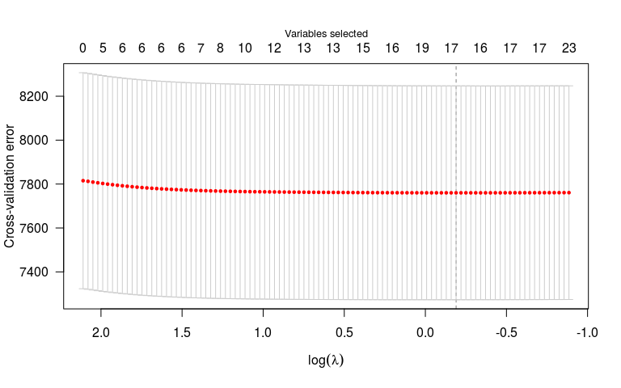

```r
plot(pooledLASSO$model)
```

```r
groupingvar <- c('age')
indices <- bigtabulate::bigsplit(X,groupingvar, splitcol=NA_real_)
indices <- indices[5:8]

# ESTIMATE MODEL WITH PARALLELIZED GROUPS
model <- foreach(i = indices, .combine='list',
                 .multicombine = TRUE,
                 .maxcombine = nrow(X),
                 .errorhandling = 'pass',
                       .packages = c("bigmemory","biglasso","biganalytics",
                                     'OpenCancer')) %do% {
                         return(
                           list(results = big.simplelasso(bigmemory::deepcopy(X, rows = i),
                                           yvar = 'incidence',
                                           labelvar = c("cancer", 'sex',
                                                        "Country_Transco", "year", "area.x", "area.y"),
                                           crossvalidation = T, nfolds = 5, returnplot = F),
                                indices = i
                           )
                         )
                       }
```

Results are stored as a list and have the same order as `indices` groups.

```r
summary(model[[1]]$results$model)
```

```
#> lasso-penalized linear regression with n=312, p=8186
#> At minimum cross-validation error (lambda=0.0469):
#> -------------------------------------------------
#>   Nonzero coefficients: 6
#>   Cross-validation error (deviance): 0.50
#>   R-squared: 0.00
#>   Signal-to-noise ratio: 0.00
#>   Scale estimate (sigma): 0.707
```

```r
summary(model[[2]]$results$model)
```

```
#> lasso-penalized linear regression with n=312, p=8186
#> At minimum cross-validation error (lambda=0.1579):
#> -------------------------------------------------
#>   Nonzero coefficients: 5
#>   Cross-validation error (deviance): 2.10
#>   R-squared: 0.01
#>   Signal-to-noise ratio: 0.01
#>   Scale estimate (sigma): 1.448
```

```r
summary(model[[3]]$results$model)
```

```
#> lasso-penalized linear regression with n=312, p=8186
#> At minimum cross-validation error (lambda=0.3036):
#> -------------------------------------------------
#>   Nonzero coefficients: 4
#>   Cross-validation error (deviance): 7.40
#>   R-squared: 0.00
#>   Signal-to-noise ratio: 0.00
#>   Scale estimate (sigma): 2.721
```

# Feature selection and linear regression on selected features

`big.model.FElasso` performs feature selection on a `big.matrix` and returns a linear regression with selected features.

```r
# POOLED OLS

pooledOLS <- big.model.FElasso(X,yvar = "incidence",returnplot = F,
                               relabel = T)

DTsummary.biglm(pooledOLS)$coefftab
```

| Coefficient | Estimate | Std. Error | Student t-stat | Pr(>\|t\|) |  |
| --- | --- | --- | --- | --- | --- |
| (Intercept) | -33.6347727607159 | 3188.53123139187 | -0.010548672827656 | 0.991583889069766 |  |
| sex | 4.71794871794853 | 2.28774331833179 | 2.06227188170255 | 0.0392254816256836 | * |
| `6741..72040` | 1.02321313325329 | 337.488069153045 | 0.00303184979493093 | 0.997581039926309 |  |
| `2531..674` | 0.363280100645929 | 362.523937768192 | 0.0010020858288211 | 0.999200485155011 |  |
| EN.ATM.NOXE.EG.ZS | 0.75846343675712 | 25.8013676428901 | 0.029396249348283 | 0.976549557009839 |  |
| `6690..5110` | -0.000875893184207645 | 0.074313209248603 | -0.0117865073122799 | 0.990596343493942 |  |
| `1057..5112` | -2.1996496284224e-06 | 0.000314700947734283 | -0.006989650473756 | 0.994423347203188 |  |
| `372..5510` | -8.35013914761975e-06 | 0.00097413635481612 | -0.00857183812752368 | 0.993161035868929 |  |
| `358..5312` | 0.000319602496135925 | 0.0311248055800432 | 0.0102684174304 | 0.991807478947558 |  |
| `2600..5510` | 2.383092077717e-06 | 0.000312182088020207 | 0.0076336605114985 | 0.993909537025863 |  |

[output cut: 2 more lines]

```r
DTsummary.biglm(pooledOLS)$modeltab
```

| Statistique | Valeur |
| --- | --- |
| Nombre Observations | 5928 |
| Nombre Paramètres | 20 |
| R2 | 0.144373349745638 |
| R2 ajusté | 0.141476357532148 |
| F-stat | 52.4674087234109 |
| Degré Liberté | 5908 |

```r
model <- big.model.FElasso(X,yvar = "incidence",
                              groupingvar = c('sex','age'),
                              returnplot = F,
                           relabel = T)

DTsummary.biglm(model[[38]]$results)$coefftab
DTsummary.biglm(model[[38]]$results)$modeltab
```

[output not shown]